# Introduction to **agricolae**

# 7 Graphics of the multiple comparison

The results of a comparison can be graphically seen with the functions `bar.group`, `bar.err` and `diffograph`.

## 7.1 bar.group

A function to plot horizontal or vertical bar, where the letters of groups of treatments is expressed. The function applies to all functions comparison treatments. Each object must use the group object previously generated by comparative function in indicating that `group = TRUE`.

### 7.1.1 Example

```r
# model <-aov (yield ~ fertilizer, data = field)
# out <-LSD.test (model, "fertilizer", group = TRUE)
# bar.group (out$group)
str(bar.group)
```

```
function (x, horiz = FALSE, ...)
 - attr(*, "srcref")= 'srcref' int [1:8] 62 3 64 3 3 3 62 64
  ..- attr(*, "srcfile")=Classes 'srcfilecopy', 'srcfile' <environment: 0x563a6777d838>
```

The Median test with option group=TRUE (default) is used in the exercise.

### 7.1.2 bar.err

A function to plot horizontal or vertical bar, where the variation of the error is expressed in every treatments. The function applies to all functions comparison treatments. Each object must use the means object previously generated by the comparison function, see Figure 7.1

```r
# model <-aov (yield ~ fertilizer, data = field)
# out <-LSD.test (model, "fertilizer", group = TRUE)
# bar.err(out$means)
str(bar.err)
```

```
function (x, variation = c("SE", "SD", "range", "IQR"), horiz = FALSE,
    bar = TRUE, ...)
 - attr(*, "srcref")= 'srcref' int [1:8] 69 3 71 3 3 3 69 71
  ..- attr(*, "srcfile")=Classes 'srcfilecopy', 'srcfile' <environment: 0x563a678c6060>
```

**variation**

SE: Standard error

SD: standard deviation

range: max-min

```r
oldpar<-par(mfrow=c(2,2),mar=c(3,3,2,1),cex=0.7)
c1<-colors()[480]; c2=colors()[65]
data(sweetpotato)
model<-aov(yield~virus, data=sweetpotato)
outHSD<- HSD.test(model, "virus",console=TRUE)
```

```
Study: model ~ "virus"

HSD Test for yield

Mean Square Error:  22

virus,  means

   yield std r Min Max
cc    24 3.6 3  22  28
fc    13 2.2 3  11  15
ff    36 7.3 3  28  42
oo    37 4.3 3  32  40

Alpha: 0.05 ; DF Error: 8
Critical Value of Studentized Range: 4.5

Minimun Significant Difference: 12

Treatments with the same letter are not significantly different.

   yield groups
oo    37      a
ff    36     ab
cc    24     bc
fc    13      c
```

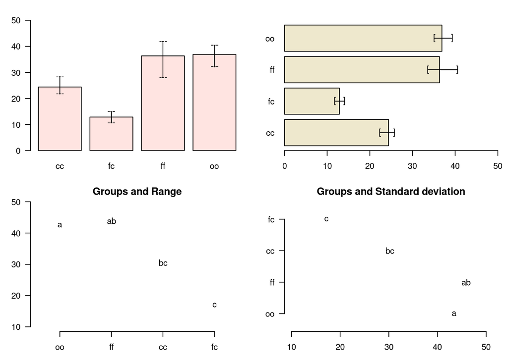

Figure 7.1: Comparison between treatments

```r
bar.err(outHSD$means, variation="range",ylim=c(0,50),col=c1,las=1)
bar.err(outHSD$means, variation="IQR",horiz=TRUE, xlim=c(0,50),col=c2,las=1)
plot(outHSD, variation="range",las=1)
plot(outHSD, horiz=TRUE, variation="SD",las=1)
```

```r
par(oldpar)
```

```r
oldpar<-par(mfrow=c(2,2),cex=0.7,mar=c(3.5,1.5,3,1))
C1<-bar.err(modelPBIB$means[1:7, ], ylim=c(0,9), col=0, main="C1",
variation="range",border=3,las=2)
C2<-bar.err(modelPBIB$means[8:15,], ylim=c(0,9), col=0, main="C2",
variation="range", border =4,las=2)
# Others graphic
C3<-bar.err(modelPBIB$means[16:22,], ylim=c(0,9), col=0, main="C3",
variation="range",border =2,las=2)
C4<-bar.err(modelPBIB$means[23:30,], ylim=c(0,9), col=0, main="C4",
variation="range", border =6,las=2)
# Lattice graphics
par(oldpar)
oldpar<-par(mar=c(2.5,2.5,1,0),cex=0.6)
bar.group(modelLattice$group,ylim=c(0,55),density=10,las=1)
par(oldpar)
```

[output not shown]

## 7.2 plot.group

It plot groups and variation of the treatments to compare. It uses the objects generated by a procedure of comparison like LSD (Fisher), duncan, Tukey (HSD), Student Newman Keul (SNK), Scheffe, Waller-Duncan, Ryan, Einot and Gabriel and Welsch (REGW), Kruskal Wallis, Friedman, Median, Waerden and other tests like Durbin, DAU, BIB, PBIB. The variation types are range (maximun and minimun), IQR (interquartile range), SD (standard deviation) and SE (standard error), see Figure 7.2.

The function: `plot.group()` and their arguments are x (output of test), `variation = c("range", "IQR", "SE", "SD")`, `horiz` (TRUE or FALSE), `xlim`, `ylim` and main are optional `plot()` parameters and others plot parameters.

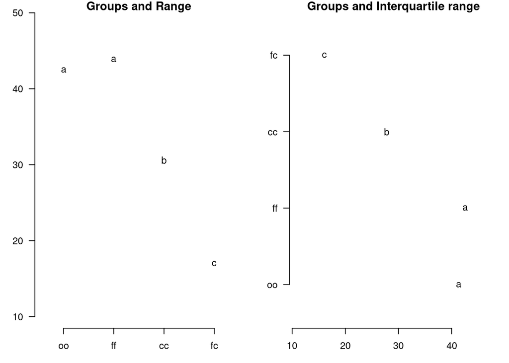

Figure 7.2: Grouping of treatments and its variation, Duncan method

```r
# model : yield ~ virus
# Important group=TRUE
oldpar<-par(mfrow=c(1,2),mar=c(3,3,1,1),cex=0.8)
x<-duncan.test(model, "virus", group=TRUE)
plot(x,las=1)
plot(x,variation="IQR",horiz=TRUE,las=1)
```

```r
par(oldpar)
```

## 7.3 diffograph

It plots bars of the averages of treatments to compare. It uses the objects generated by a procedure of comparison like LSD (Fisher), duncan, Tukey (HSD), Student Newman Keul (SNK), Scheffe, Ryan, Einot and Gabriel and Welsch (REGW), Kruskal Wallis, Friedman and Waerden (Hsu, 1996) see Figure 7.3.

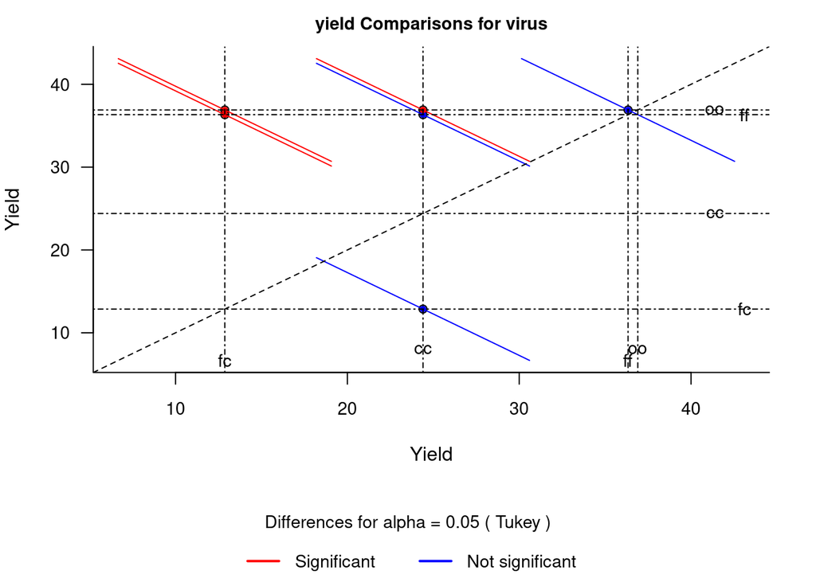

Figure 7.3: Mean-Mean scatter plot representation of the Tukey method

```r
# function (x, main = NULL, color1 = "red", color2 = "blue",
#    color3 = "black", cex.axis = 0.8, las = 1, pch = 20,
#    bty = "l", cex = 0.8, lwd = 1, xlab = "", ylab = "",
#   ...)
# model : yield ~ virus
# Important group=FALSE
x<-HSD.test(model, "virus", group=FALSE)
diffograph(x,cex.axis=0.9,xlab="Yield",ylab="Yield",cex=0.9)
```

# 8 Stability Analysis

In **agricolae** there are two methods for the study of stability and the AMMI model. These are: a parametric model for a simultaneous selection in yield and stability “SHUKLA’S STABILITY VARIANCE AND KANG’S”, (Kang, 1993) and a non-parametric method of Haynes, based on the data range.

## 8.1 Parametric Stability

Use the parametric model, function `stability.par`.

```r
options(digit=2)
f <- system.file("external/dataStb.csv", package="agricolae")
dataStb<-read.csv(f)
stability.par(dataStb, rep=4, MSerror=1.8, alpha=0.1, main="Genotype",console=TRUE)
```

```
 INTERACTIVE PROGRAM FOR CALCULATING SHUKLA'S STABILITY VARIANCE AND KANG'S
                        YIELD - STABILITY (YSi) STATISTICS
 Genotype
 Environmental index  - covariate

 Analysis of Variance

               Df    Sum Sq  Mean Sq F value Pr(>F)
Total         203 2964.1716
Genotypes      16  186.9082  11.6818    4.17 <0.001
Environments   11 2284.0116 207.6374  115.35 <0.001
Interaction   176  493.2518   2.8026    1.56 <0.001
Heterogeneity  16   44.8576   2.8036       1  0.459
Residual      160  448.3942   2.8025    1.56 <0.001
Pooled Error  576                1.8

 Genotype. Stability statistics

  Mean Sigma-square  . s-square  . Ecovalence
A  7.4         2.47 ns     2.45 ns       25.8
B  6.8         1.60 ns     1.43 ns       17.4
C  7.2         0.57 ns     0.63 ns        7.3
D  6.8         2.61 ns     2.13 ns       27.2
E  7.1         1.86 ns     2.05 ns       19.9
F  6.9         3.58  *     3.95  *       36.5
G  7.8         3.58  *     3.96  *       36.6
H  7.9         2.72 ns     2.12 ns       28.2
I  7.3         4.25 **     3.94  *       43.0
J  7.1         2.27 ns     2.51 ns       23.9
K  6.4         2.56 ns     2.55 ns       26.7
L  6.9         1.56 ns     1.73 ns       16.9
M  6.8         3.48  *     3.28 ns       35.6
N  7.5         5.16 **     4.88 **       51.9
O  7.7         2.38 ns     2.64 ns       24.9
P  6.4         3.45  *     3.71  *       35.3
Q  6.2         3.53  *     3.69  *       36.1


Signif. codes:  0 '**' 0.01 '*' 0.05 'ns' 1

```

[output cut: 13 more lines]

```
K   6.4    3       -2        1     2.56           0   1
L   6.9    7       -1        6     1.56           0   6
M   6.8    6       -1        5     3.48          -4   1
N   7.5   14        1       15     5.16          -8   7   +
O   7.7   15        2       17     2.38           0  17   +
P   6.4    2       -2        0     3.45          -4  -4
Q   6.2    1       -3       -2     3.53          -4  -6

 Yield Mean: 7.1
 YS    Mean: 6.8
 LSD (0.05): 0.45
 - - - - - - - - - - -
 +   selected genotype
 ++  Reference: Kang, M. S. 1993. Simultaneous selection for yield
 and stability: Consequences for growers. Agron. J. 85:754-757.
```

For 17 genotypes, the identification is made by letters. An error variance of 2 and 4 repetitions is assumed.

### 8.1.1 Analysis

```r
output <- stability.par(dataStb, rep=4, MSerror=2)
names(output)
```

```
[1] "analysis"   "statistics" "stability"
```

```r
print(output$stability)
```

```
  Yield Rank Adj.rank Adjusted Stab.var Stab.rating YSi ...
A   7.4   13        1       14     2.47           0  14   +
B   6.8    4       -1        3     1.60           0   3
C   7.2   11        1       12     0.57           0  12   +
D   6.8    4       -1        3     2.61           0   3
E   7.1    9        1       10     1.86           0  10   +
F   6.9    8       -1        7     3.58          -2   5
G   7.8   16        2       18     3.58          -2  16   +
H   7.9   17        2       19     2.72           0  19   +
I   7.3   12        1       13     4.25          -4   9   +
J   7.1   10        1       11     2.27           0  11   +
K   6.4    3       -2        1     2.56           0   1
L   6.9    7       -1        6     1.56           0   6
M   6.8    6       -1        5     3.48          -2   3
N   7.5   14        1       15     5.16          -8   7
O   7.7   15        2       17     2.38           0  17   +
P   6.4    2       -2        0     3.45          -2  -2
Q   6.2    1       -2       -1     3.53          -2  -3
```

The selected genotypes are: A, C, E, G, H, I, J and O. These genotypes have a higher yield and a lower variation. to see output$analysis, the interaction is significant.

If for example there is an environmental index, it can be added as a covariate In the first five locations. For this case, the altitude of the localities is included.

```r
data5<-dataStb[,1:5]
altitude<-c(1200, 1300, 800, 1600, 2400)
stability <- stability.par(data5,rep=4,MSerror=2, cova=TRUE, name.cov= "altitude",
file.cov=altitude)
```

## 8.2 Non-parametric Stability

For non-parametric stability, the function in **agricolae** is `stability.nonpar()`. The names of the genotypes should be included in the first column, and in the other columns, the response by environments (Haynes et al., 1998).

### 8.2.1 Analysis

```r
data <- data.frame(name=row.names(dataStb), dataStb)
output<-stability.nonpar(data, "YIELD", ranking=TRUE)
names(output)
```

```
[1] "ranking"    "statistics"
```

```r
output$statistics
```

```
  MEAN es1 es2  vs1 vs2 chi.ind chi.sum
1  7.1 5.6  24 0.72  47     8.8      28
```

## 8.3 AMMI

The model AMMI uses the biplot constructed through the principal components generated by the interaction environment-genotype. If there is such interaction, the percentage of the two principal components would explain more than the 50% of the total variation; in such case, the biplot would be a good alternative to study the interaction environment-genotype (Crossa, 1990).

The data for AMMI should come from similar experiments conducted in different environments. Homogeneity of variance of the experimental error, produced in the different environments, is required. The analysis is done by combining the experiments.

The data can be organized in columns, thus: environment, genotype, repetition, and variable.

The data can also be the averages of the genotypes in each environment, but it is necessary to consider a harmonious average for the repetitions and a common variance of the error. The data should be organized in columns: environment, genotype, and variable.

When performing AMMI, this generates the Biplot, Triplot and Influence graphics, see Figure 8.1.

### 8.3.1 AMMI structure

```r
  str(AMMI)
```

```
function (ENV, GEN, REP, Y, MSE = 0, console = FALSE, PC = FALSE)
 - attr(*, "srcref")= 'srcref' int [1:8] 86 5 260 5 5 5 86 260
  ..- attr(*, "srcfile")=Classes 'srcfilecopy', 'srcfile' <environment: 0x563a672de118>
```

### 8.3.2 plot.AMMI structure, plot()

```r
  str(plot.AMMI)
```

```r
data(plrv)
model<-with(plrv,AMMI(Locality, Genotype, Rep, Yield, console=FALSE))
names(model)
```

```
[1] "ANOVA"    "genXenv"  "analysis" "means"    "biplot"   "PC"
```

```r
model$ANOVA
```

```
Analysis of Variance Table

Response: Y
           Df Sum Sq Mean Sq F value  Pr(>F)
ENV         5 122284   24457  257.04 9.1e-12 ***
REP(ENV)   12   1142      95    2.57  0.0029 **
GEN        27  17533     649   17.54 < 2e-16 ***
ENV:GEN   135  23762     176    4.75 < 2e-16 ***
Residuals 324  11998      37
---
Signif. codes:  0 '***' 0.001 '**' 0.01 '*' 0.05 '.' 0.1 ' ' 1
```

```r
model$analysis
```

```
    percent acum Df Sum.Sq Mean.Sq F.value   Pr.F
PC1    56.3   56 31  13369     431   11.65 0.0000
PC2    27.1   83 29   6428     222    5.99 0.0000
PC3     9.4   93 27   2242      83    2.24 0.0005
PC4     4.3   97 25   1028      41    1.11 0.3286
PC5     2.9  100 23    696      30    0.82 0.7059
```

```r
pc <- model$analysis[, 1]
pc12<-sum(pc[1:2])
pc123<-sum(pc[1:3])
```

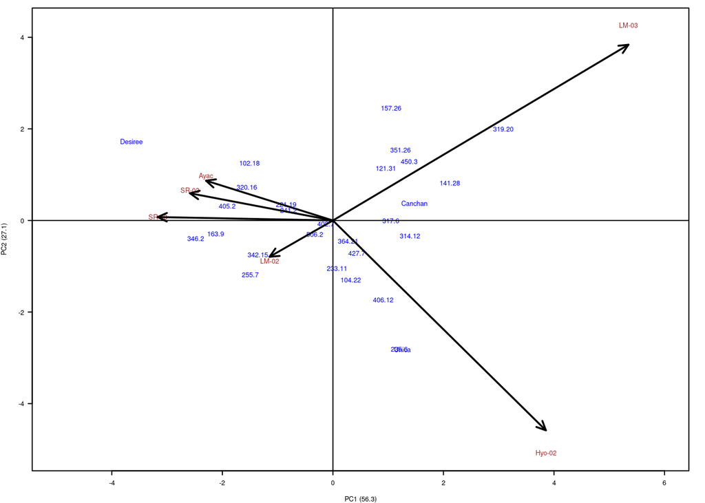

Figure 8.1: Biplot

```r
oldpar<-par(cex=0.4,mar=c(4,4,1,2))
plot(model,type=1,las=1,xlim=c(-5,6))
```

```r
par(oldpar)
```

In this case, the interaction is significant. The first two components explain 83.4 %; then the biplot can provide information about the interaction genotype-environment. With the triplot, 92.8% would be explained.

**To triplot require klaR package. in R execute:**

```r
plot(model,type=2,las=1)
```

## 8.4 AMMI index and yield stability

Calculate AMMI stability value (ASV) and Yield stability index (YSI) (Purchase, 1997; N. et al., 2008).

```r
data(plrv)
model<- with(plrv,AMMI(Locality, Genotype, Rep, Yield, console=FALSE))
index<-index.AMMI(model)
# Crops with improved stability according AMMI.
print(index[order(index[,3]),])
```

```
         ASV YSI rASV rYSI means
402.7   0.28  20    1   19    27
364.21  0.72  12    2   10    34
506.2   0.75  14    3   11    33
233.11  1.06  21    4   17    29
427.7   1.15  12    5    7    36
104.22  1.46  19    6   13    31
241.2   1.68  29    7   22    26
221.19  1.80  34    8   26    23
317.6   2.19  18    9    9    35
121.31  2.29  25   10   15    30
406.12  2.56  23   11   12    33
314.12  2.92  30   12   18    28
342.15  2.92  37   13   24    26
351.26  2.98  22   14    8    36
Canchan 3.10  35   15   20    27
450.3   3.14  22   16    6    36
157.26  3.29  22   17    5    37
320.16  3.32  39   18   21    26
255.7   3.33  33   19   14    31
102.18  3.38  43   20   23    26
235.6   3.76  25   21    4    39
Unica   3.84  24   22    2    39
405.2   3.98  39   23   16    29
163.9   4.43  51   24   27    21
141.28  4.47  26   25    1    40
346.2   5.18  51   26   25    24
319.20  6.72  30   27    3    39
Desiree 7.78  56   28   28    16
```

```r
# Crops with better response and improved stability according AMMI.
print(index[order(index[,4]),])
```

```
         ASV YSI rASV rYSI means
141.28  4.47  26   25    1    40
Unica   3.84  24   22    2    39
319.20  6.72  30   27    3    39
235.6   3.76  25   21    4    39
157.26  3.29  22   17    5    37
450.3   3.14  22   16    6    36
427.7   1.15  12    5    7    36
351.26  2.98  22   14    8    36
317.6   2.19  18    9    9    35
364.21  0.72  12    2   10    34
506.2   0.75  14    3   11    33
406.12  2.56  23   11   12    33
104.22  1.46  19    6   13    31
255.7   3.33  33   19   14    31
121.31  2.29  25   10   15    30
405.2   3.98  39   23   16    29
233.11  1.06  21    4   17    29
314.12  2.92  30   12   18    28
402.7   0.28  20    1   19    27
Canchan 3.10  35   15   20    27
320.16  3.32  39   18   21    26
241.2   1.68  29    7   22    26
102.18  3.38  43   20   23    26
342.15  2.92  37   13   24    26
346.2   5.18  51   26   25    24
221.19  1.80  34    8   26    23
163.9   4.43  51   24   27    21
Desiree 7.78  56   28   28    16
```

# 9 Special Functions

## 9.1 Consensus of dendrogram

Consensus is the degree or similarity of the vertexes of a tree regarding its branches of the constructed dendrogram. The function to apply is `consensus()`.

The data correspond to a table, with the name of the individuals and the variables in the rows and columns respectively. For the demonstration, we will use the `pamCIP` data of **agricolae**, which correspond to molecular markers of 43 entries of a germplasm bank (rows) and 107 markers (columns).

The program identifies duplicates in the rows and can operate in both cases. The result is a dendrogram, in which the consensus percentage is included, see Figure 9.1.

```r
oldpar<-par(cex=0.6,mar=c(3,3,2,1))
data(pamCIP)
rownames(pamCIP)<-substr(rownames(pamCIP),1,6)
output<-consensus(pamCIP,distance="binary", method="complete", nboot=5)
```

```
Duplicates: 18
New data  : 25 Records

Consensus hclust

Method distance: binary
Method cluster : complete
rows and cols  : 25 107
n-bootstrap    : 5
Run time       : 0.72 secs
```

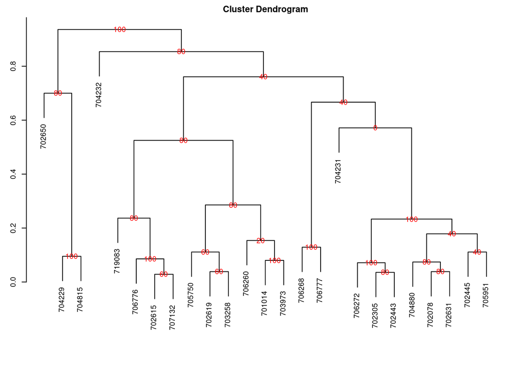

Figure 9.1: Dendrogram, production by `consensus`

```r
par(oldpar)
```

When the dendrogram is complex, it is convenient to extract part of it with the function `hcut()`, see Figure 9.2.

```r
oldpar<-par(cex=0.6,mar=c(3,3,1.5,1))
out1<- hcut(output,h=0.4,group=8,type="t",edgePar = list(lty=1:2, col=colors()[c(42,84)]),
main="group 8" ,col.text="blue",cex.text=1,las=1)
```

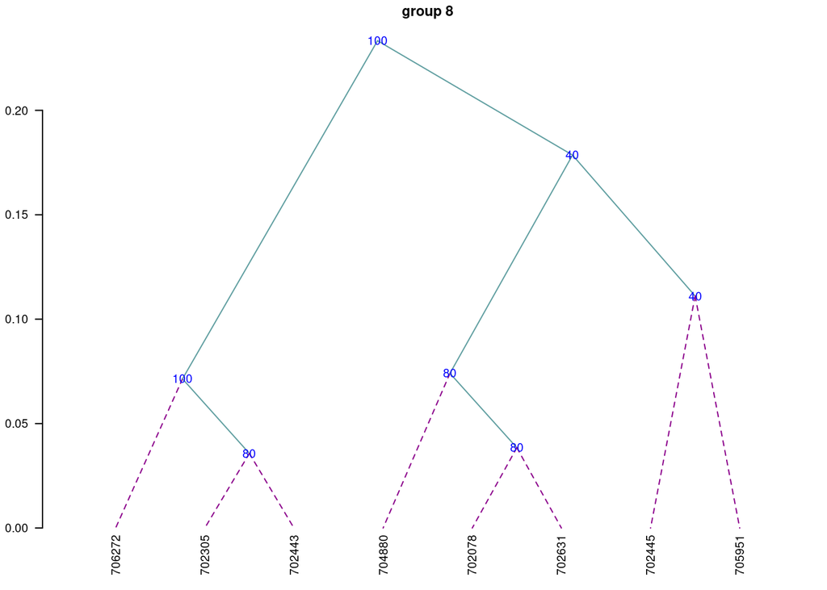

Figure 9.2: Dendrogram, production by `hcut()`

```r
par(oldpar)
```

The obtained object “output” contains information about the process:

```r
names(output)
```

```
[1] "table.dend" "dendrogram" "duplicates"
```

**Construct a classic dendrogram, execute procedure in R**

use the previous result ‘output’

```r
dend <- as.dendrogram(output$dendrogram)
data <- output$table.dend
head(output$table.dend)
```

```
   X1  X2 xaxis height percentage groups
1  -6 -24   7.5  0.029         60   6-24
2  -3  -4  19.5  0.036         80    3-4
3  -2  -8  22.5  0.038         80    2-8
4  -7 -10  10.5  0.038         60   7-10
5 -21   2  18.8  0.071        100 3-4-21
6 -16   3  21.8  0.074         80 2-8-16
```

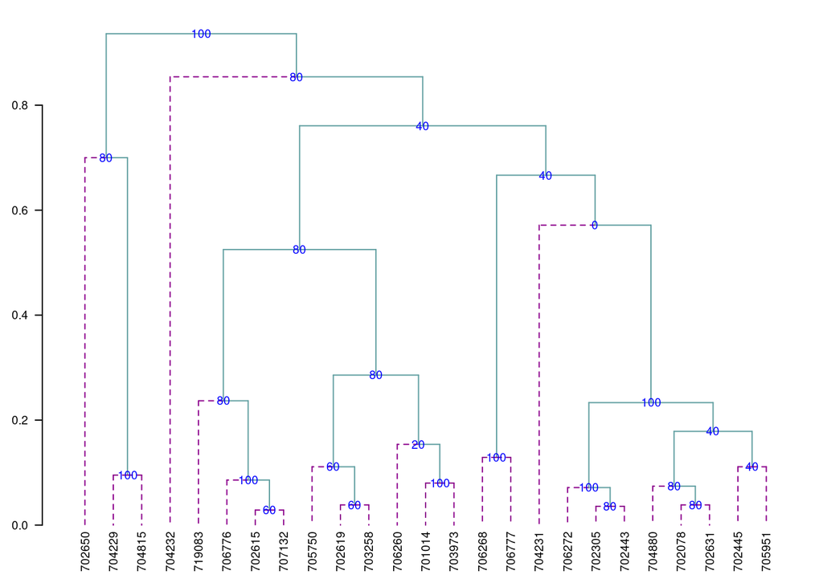

```r
oldpar<-par(mar=c(3,3,1,1),cex=0.6)
plot(dend,type="r",edgePar = list(lty=1:2, col=colors()[c(42,84)]) ,las=1)
text(data[,3],data[,4],data[,5],col="blue",cex=1)
```

```r
par(oldpar)
```

## 9.2 Montecarlo

It is a method for generating random numbers of an unknown distribution. It uses a data set and, through the cumulative behavior of its relative frequency, generates the possible random values that follow the data distribution. These new numbers are used in some simulation process.

The probability density of the original and simulated data can be compared, see Figure 9.3.

```r
data(soil)
# set.seed(9473)
simulated <- montecarlo(soil$pH,1000)
h<-graph.freq(simulated,nclass=7,plot=FALSE)
```

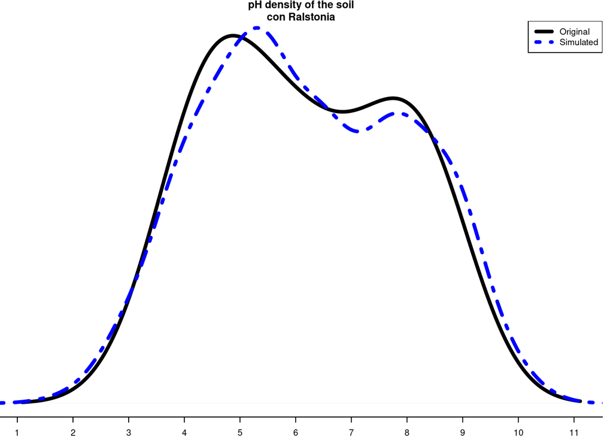

Figure 9.3: Distribution of the simulated and the original data

```r
oldpar<-par(mar=c(2,0,2,1),cex=0.6)
plot(density(soil$pH),axes=FALSE,main="pH density of the soil\ncon Ralstonia",xlab="",lwd=4)
lines(density(simulated), col="blue", lty=4,lwd=4)
axis(1,0:12)
legend("topright",c("Original","Simulated"),lty=c(1,4),col=c("black", "blue"), lwd=4)
```

```r
par(oldpar)
```

1000 data was simulated, being the frequency table:

```r
round(table.freq(h),2)
```

```
  Lower Upper Main Frequency Percentage   CF   CPF
1   1.5   2.8  2.1        19        1.9   19   1.9
2   2.8   4.1  3.5       120       12.0  139  13.9
3   4.1   5.4  4.8       234       23.4  373  37.3
4   5.4   6.7  6.0       233       23.3  606  60.6
5   6.7   8.0  7.3       182       18.2  788  78.8
6   8.0   9.3  8.7       176       17.6  964  96.4
7   9.3  10.6  9.9        36        3.6 1000 100.0
```

**Some statistics, original data:**

```r
summary(soil$pH)
```

```
   Min. 1st Qu.  Median    Mean 3rd Qu.    Max.
    3.8     4.7     6.1     6.2     7.6     8.4
```

**Some statistics, montecarlo simulate data:**

```r
summary(simulated)
```

```
   Min. 1st Qu.  Median    Mean 3rd Qu.    Max.
    1.6     4.8     6.1     6.2     7.8    10.6
```

## 9.3 Re-Sampling in linear model

It uses the permutation method for the calculation of the probabilities of the sources of variation of ANOVA according to the linear regression model or the design used. The principle is that the Y response does not depend on the averages proposed in the model; hence, the Y values can be permutated and many model estimates can be constructed. On the basis of the patterns of the random variables of the elements under study, the probability is calculated in order to measure the significance.

For a variance analysis, the data should be prepared similarly. The function to use is: `resampling.model()`.

```r
data(potato)
potato[,1]<-as.factor(potato[,1])
potato[,2]<-as.factor(potato[,2])
model<-"cutting~variety + date + variety:date"
analysis<-resampling.model(model, potato, k=100)
Xsol<-as.matrix(round(analysis$solution,2))
print(Xsol,na.print = "")
```

```
             Df Sum Sq Mean Sq F value Pr(>F) Resampling
variety       1   25.1    25.1     7.3   0.02       0.02
date          2   13.9     7.0     2.0   0.18       0.19
variety:date  2    4.8     2.4     0.7   0.51       0.50
Residuals    12   41.5     3.5
```

The function `resampling.model()` can be used when the errors have a different distribution from normal.

## 9.4 Simulation in linear model

Under the assumption of normality, the function generates pseudo experimental errors under the proposed model, and determines the proportion of valid results according to the analysis of variance found.

The function is: `simulation.model()`. The data are prepared in a table, similarly to an analysis of variance.

Considering the example proposed in the previous procedure:

```r
simModel <- simulation.model(model, potato, k=100,console=TRUE)
```

```
Simulation of experiments
Under the normality assumption
- - - - - - - - - - - - - - - -
Proposed model: cutting~variety + date + variety:date
Analysis of Variance Table

Response: cutting
             Df Sum Sq Mean Sq F value Pr(>F)
variety       1   25.1   25.09    7.26   0.02 *
date          2   13.9    6.95    2.01   0.18
variety:date  2    4.9    2.43    0.70   0.51
Residuals    12   41.5    3.46
---
Signif. codes:  0 '***' 0.001 '**' 0.01 '*' 0.05 '.' 0.1 ' ' 1
---
Validation of the analysis of variancia for the proposed model
Simulations: 100

             Df F value % Acceptance % Rejection  Criterion
variety       1     7.3           60          40 acceptable
date          2     2.0           66          34 acceptable
variety:date  2     0.7           70          30 acceptable
---
```

The validation is referred to the percentage of decision results equal to the result of the ANOVA decision. Thus, 70% of the results simulated on the interaction variety*date gave the same result of acceptance or rejection obtained in the ANOVA.

## 9.5 Path Analysis

It corresponds to the “path analysis” method. The data correspond to correlation matrices of the independent ones with the dependent matrix (XY) and between the independent ones (XX).

It is necessary to assign names to the rows and columns in order to identify the direct and indirect effects.

```r
corr.x<- matrix(c(1,0.5,0.5,1),c(2,2))
corr.y<- rbind(0.6,0.7)
names<-c("X1","X2")
dimnames(corr.x)<-list(names,names)
dimnames(corr.y)<-list(names,"Y")
output<-path.analysis(corr.x,corr.y)
```

```
Direct(Diagonal) and indirect effect path coefficients
======================================================
     X1   X2
X1 0.33 0.27
X2 0.17 0.53

Residual Effect^2 =  0.43
```

```r
output
```

```
$Coeff
     X1   X2
X1 0.33 0.27
X2 0.17 0.53

$Residual
[1] 0.43
```

## 9.6 Line X Tester

It corresponds to a crossbreeding analysis of a genetic design. The data should be organized in a table. Only four columns are required: repetition, females, males, and response. In case it corresponds to progenitors, the females or males field will only be filled with the corresponding one. See the heterosis data (Singh and Chaudhary, 1979).

### 9.6.1 Example with the heterosis data, locality 2

```r
     Replication   Female   Male   v2
     109           1     LT-8  TS-15 2.65s
     110           1     LT-8 TPS-13 2.26
     ...
     131           1 Achirana TPS-13 3.55
     132           1 Achirana TPS-67 3.05
     ...
     140           1 Achirana   <NA> 3.35
     ...
     215           3     <NA> TPS-67 2.91
```

where `<NA>` is empty.

If it is a progeny, it comes from a “Female” and a “Male.” If it is a progenitor, it will only be “Female” or “Male.”

The following example corresponds to data of the locality 2:

24 progenies 8 females 3 males 3 repetitions

They are 35 treatments (24, 8, 3) applied to three blocks.

```r
rm(list=ls())
options(digits = 2)
data(heterosis)
str(heterosis)
```

```
'data.frame':   324 obs. of  11 variables:
 $ Place      : num  1 1 1 1 1 1 1 1 1 1 ...
 $ Replication: num  1 1 1 1 1 1 1 1 1 1 ...
 $ Treatment  : num  1 2 3 4 5 6 7 8 9 10 ...
 $ Factor     : Factor w/ 3 levels "Control","progenie",..: 2 2 2 2 2 2 2 2 2 2 ...
 $ Female     : Factor w/ 8 levels "Achirana","LT-8",..: 2 2 2 6 6 6 7 7 7 8 ...
 $ Male       : Factor w/ 3 levels "TPS-13","TPS-67",..: 3 1 2 3 1 2 3 1 2 3 ...
 $ v1         : num  0.948 1.052 1.05 1.058 1.123 ...
 $ v2         : num  1.65 2.2 1.88 2 2.45 2.63 2.75 3 2.51 1.93 ...
 $ v3         : num  17.2 17.8 15.6 16 16.5 ...
 $ v4         : num  9.93 12.45 9.3 12.77 14.13 ...
 $ v5         : num  102.6 107.4 120.5 83.8 90.4 ...
```

```r
site2<-subset(heterosis,heterosis[,1]==2)
site2<-subset(site2[,c(2,5,6,8)],site2[,4]!="Control")
output1<-with(site2,lineXtester(Replication, Female, Male, v2))
```

```
ANALYSIS LINE x TESTER:  v2

ANOVA with parents and crosses
==============================
                     Df  Sum Sq Mean Sq F value Pr(>F)
Replications          2  0.5192  0.2596    9.80 0.0002
Treatments           34 16.1016  0.4736   17.88 0.0000
Parents              10  7.7315  0.7731   29.19 0.0000
Parents vs. Crosses   1  0.0051  0.0051    0.19 0.6626
Crosses              23  8.3650  0.3637   13.73 0.0000
Error                68  1.8011  0.0265
Total               104 18.4219

ANOVA for line X tester analysis
================================
                Df Sum Sq Mean Sq F value Pr(>F)
Lines            7   4.98   0.711     3.6  0.019
Testers          2   0.65   0.325     1.7  0.226
Lines X Testers 14   2.74   0.196     7.4  0.000
Error           68   1.80   0.026

ANOVA for line X tester analysis including parents
==================================================
                     Df  Sum Sq Mean Sq F value Pr(>F)
Replications          2  0.5192  0.2596    9.80 0.0002
Treatments           34 16.1016  0.4736   17.88 0.0000
Parents              10  7.7315  0.7731   29.19 0.0000
Parents vs. Crosses   1  0.0051  0.0051    0.19 0.6626
Crosses              23  8.3650  0.3637   13.73 0.0000
Lines                 7  4.9755  0.7108    3.63 0.0191
Testers               2  0.6494  0.3247    1.66 0.2256
Lines X Testers      14  2.7401  0.1957    7.39 0.0000
Error                68  1.8011  0.0265
Total               104 18.4219

GCA Effects:
===========
Lines Effects:
Achirana     LT-8     MF-I    MF-II  Serrana    TPS-2   TPS-25    TPS-7
   0.022   -0.338    0.199   -0.449    0.058   -0.047    0.414    0.141
```

[output cut: 29 more lines]

```
Cov H.S. (line)   : 0.057
Cov H.S. (tester) : 0.0054
Cov H.S. (average): 0.0039
Cov F.S. (average): 0.13
F = 0, Adittive genetic variance: 0.015
F = 1, Adittive genetic variance: 0.0077
F = 0, Variance due to Dominance: 0.11
F = 1, Variance due to Dominance: 0.056

Proportional contribution of lines, testers
 and their interactions to total variance
===========================================
Contributions of lines  : 59
Contributions of testers: 7.8
Contributions of lxt    : 33
```

```r
options(digits = 7)
```

## 9.7 Soil Uniformity

The Smith index is an indicator of the uniformity, used to determine the parcel size for research purposes. The data correspond to a matrix or table that contains the response per basic unit, a number of n rows x m columns, and a total of n*m basic units.

For the test, we will use the rice file. The graphic is a result with the adjustment of a model for the plot size and the coefficient of variation, see Figure 9.4.

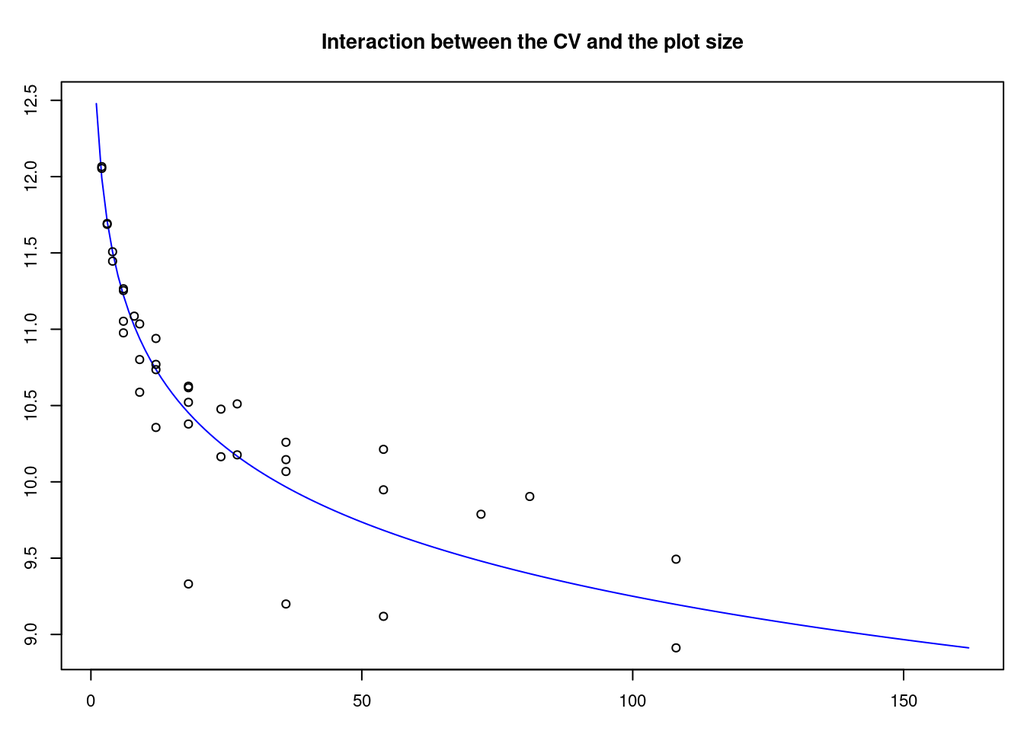

Figure 9.4: Adjustment curve for the optimal size of plot

```r
oldpar<-par(mar=c(3,3,4,1),cex=0.7)
data(rice)
table<-index.smith(rice, col="blue",
 main="Interaction between the CV and the plot size",type="l",xlab="Size")
```

```r
par(oldpar)
```

```r
uniformity <- data.frame(table$uniformity)
head(uniformity)
```

```
  Size Width Length plots       Vx   CV
1    1     1      1   648 9044.539 13.0
2    2     1      2   324 7816.068 12.1
3    2     2      1   324 7831.232 12.1
4    3     1      3   216 7347.975 11.7
5    3     3      1   216 7355.216 11.7
6    4     1      4   162 7047.717 11.4
```

## 9.8 Confidence Limits In Biodiversity Indices

The biodiversity indices are widely used for measuring the presence of living things in an ecological area. Many programs indicate their value. The function of **agricolae** is also to show the confidence intervals, which can be used for a statistical comparison. Use the bootstrap procedure. The data are organized in a table; the species are placed in a column; and in another one, the number of individuals. The indices that can be calculated with the function `index.bio()` of **agricolae** are: `Margalef`, `Simpson.Dom`, `Simpson.Div`, `Berger.Parker`, `McIntosh`, and `Shannon`.

In the example below, we will use the data obtained in the locality of Paracsho, district of Huasahuasi, province of Tarma in the department of Junin.

The evaluation was carried out in the parcels on 17 November 2005, without insecticide application. The counted specimens were the following:

```r
data(paracsho)
species <- paracsho[79:87,4:6]
species
```

```
         Orden        Family Number.of.specimens
79     DIPTERA     TIPULIDAE                   3
80 LEPIDOPTERA     NOCTUIDAE                   1
81   NOCTUIDAE     PYRALIDAE                   3
82   HEMIPTERA  ANTHOCORIDAE                   1
83     DIPTERA    TACHINIDAE                  16
84     DIPTERA  ANTHOCORIDAE                   3
85     DIPTERA SCATOPHAGIDAE                   5
86     DIPTERA     SYRPHIDAE                   1
87     DIPTERA      MUSCIDAE                   3
```

**The Shannon index is:**

```r
output <- index.bio(species[,3],method="Shannon",level=95,nboot=200)
```

```
Method: Shannon

The index: 2.541336

95 percent confidence interval:
 2.22808 ; 3.07635
```

## 9.9 Correlation

The function `correlation()` of **agricolae** makes the correlations through the methods of Pearson, Spearman and Kendall for vectors and/or matrices. If they are two vectors, the test is carried out for one or two lines; if it is a matrix one, it determines the probabilities for a difference, whether it is greater or smaller.

For its application, consider the soil data: `data(soil)`.

```r
data(soil)
correlation(soil[,2:4],method="pearson")
```

```
$correlation
        pH   EC CaCO3
pH    1.00 0.55  0.73
EC    0.55 1.00  0.32
CaCO3 0.73 0.32  1.00

$pvalue
               pH        EC       CaCO3
pH    1.000000000 0.0525330 0.004797027
EC    0.052532997 1.0000000 0.294159813
CaCO3 0.004797027 0.2941598 1.000000000

$n.obs
[1] 13
```

```r
with(soil,correlation(pH,soil[,3:4],method="pearson"))
```

```
$correlation
     EC CaCO3
pH 0.55  0.73

$pvalue
       EC  CaCO3
pH 0.0525 0.0048

$n.obs
[1] 13
```

## 9.10 tapply.stat()

Gets a functional calculation of variables grouped by study factors.

### 9.10.1 Application with **agricolae** data

`max(yield)-min(yield)` by farmer

```r
data(RioChillon)
with(RioChillon$babies,tapply.stat(yield,farmer,function(x) max(x)-min(x)))
```

```
            farmer yield
1  AugustoZambrano   7.5
2        Caballero  13.4
3       ChocasAlto  14.1
4       FelixAndia  19.4
5      Huarangal-1   9.8
6      Huarangal-2   9.1
7      Huarangal-3   9.4
8         Huatocay  19.4
9 IgnacioPolinario  13.1
```

It corresponds to the range of variation in the farmers’ yield.

The function `tapply` can be used directly or with function.

If A is a table with columns 1,2 and 3 as category, and 5,6 and 7 as variables, then the following procedures are valid:

```r
tapply.stat(A[,5:7], A[,1:3],mean)
tapply.stat(A[,5:7], A[,1:3],function(x) mean(x,na.rm=TRUE))
tapply.stat(A[,c(7,6)], A[,1:2],function(x) sd(x)*100/mean(x))
```

## 9.11 Coefficient of variation of an experiment

If `model` is the object resulting from an analysis of variance of the function `aov()` or `lm()` of **R**, then the function `cv.model()` calculates the **coefficient of variation**.

```r
data(sweetpotato)
model <- model<-aov(yield ~ virus, data=sweetpotato)
cv.model(model)
```

```
[1] 17.1666
```

## 9.12 Skewness and kurtosis

The skewness and kurtosis results, obtained by **agricolae**, are equal to the ones obtained by SAS, MiniTab, SPSS, InfoStat, and Excel.

If x represents a data set:

```r
x<-c(3,4,5,2,3,4,5,6,4,NA,7)
```

### 9.12.1 Skewness

```r
skewness(x)
```

```
[1] 0.3595431
```

### 9.12.2 Kurtosis

```r
kurtosis(x)
```

```
[1] -0.1517996
```

## 9.13 Tabular value of Waller-Duncan

The function Waller determines the tabular value of Waller-Duncan. For the calculation, value F is necessary, calculated from the analysis of variance of the study factor, with its freedom degrees and the estimate of the variance of the experimental error. Value K, parameter of the function is the ratio between the two types of errors (I and II). To use it, a value associated with the alpha level is assigned. When the alpha level is 0.10, 50 is assigned to K; for 0.05, K=100; and for 0.01, K=500. K can take any value.

```r
q<-5
f<-15
K<-seq(10,1000,100)
n<-length(K)
y<-rep(0,3*n)
dim(y)<-c(n,3)
for(i in 1:n) y[i,1]<-waller(K[i],q,f,Fc=2)
for(i in 1:n) y[i,2]<-waller(K[i],q,f,Fc=4)
for(i in 1:n) y[i,3]<-waller(K[i],q,f,Fc=8)
```

### 9.13.1 Function of Waller to different value of parameters K and Fc

The next procedure illustrates the function for different values of K with freedom degrees of 5 for the numerator and 15 for the denominator, and values of calculated F, equal to 2, 4, and 8.

```r
oldpar<-par(mar=c(3,3,4,1),cex=0.7)
plot(K,y[,1],type="l",col="blue",ylab="waller",bty="l")
lines(K,y[,2],type="l",col="brown",lty=2,lwd=2)
lines(K,y[,3],type="l",col="green",lty=4,lwd=2)
legend("topleft",c("2","4","8"),col=c("blue","brown","green"),lty=c(1,8,20),
lwd=2,title="Fc")
title(main="Waller in function of K")
par(oldpar)
```

[output not shown]

## 9.14 Generating table Waller-Duncan

```r
K<-100
Fc<-1.2
q<-c(seq(6,20,1),30,40,100)
f<-c(seq(4,20,2),24,30)
n<-length(q)
m<-length(f)
W.D <-rep(0,n*m)
dim(W.D)<-c(n,m)
for (i in 1:n) {
for (j in 1:m) {
W.D[i,j]<-waller(K, q[i], f[j], Fc)
}}
W.D<-round(W.D,2)
dimnames(W.D)<-list(q,f)
cat("table: Waller Duncan k=100, F=1.2")
```

```
table: Waller Duncan k=100, F=1.2
```

```r
print(W.D)
```

```
       4    6    8   10   12   14   16   18   20   24   30
6   2.85 2.87 2.88 2.89 2.89 2.89 2.89 2.88 2.88 2.88 2.88
7   2.85 2.89 2.92 2.93 2.94 2.94 2.94 2.94 2.94 2.94 2.94
8   2.85 2.91 2.94 2.96 2.97 2.98 2.99 2.99 2.99 3.00 3.00
9   2.85 2.92 2.96 2.99 3.01 3.02 3.03 3.03 3.04 3.04 3.05
10  2.85 2.93 2.98 3.01 3.04 3.05 3.06 3.07 3.08 3.09 3.10
11  2.85 2.94 3.00 3.04 3.06 3.08 3.09 3.10 3.11 3.12 3.14
12  2.85 2.95 3.01 3.05 3.08 3.10 3.12 3.13 3.14 3.16 3.17
13  2.85 2.96 3.02 3.07 3.10 3.12 3.14 3.16 3.17 3.19 3.20
14  2.85 2.96 3.03 3.08 3.12 3.14 3.16 3.18 3.19 3.21 3.23
15  2.85 2.97 3.04 3.10 3.13 3.16 3.18 3.20 3.21 3.24 3.26
16  2.85 2.97 3.05 3.11 3.15 3.18 3.20 3.22 3.24 3.26 3.29
17  2.85 2.98 3.06 3.12 3.16 3.19 3.22 3.24 3.26 3.28 3.31
18  2.85 2.98 3.07 3.13 3.17 3.20 3.23 3.25 3.27 3.30 3.33
19  2.85 2.98 3.07 3.13 3.18 3.22 3.24 3.27 3.29 3.32 3.35
20  2.85 2.99 3.08 3.14 3.19 3.23 3.26 3.28 3.30 3.33 3.37
30  2.85 3.01 3.11 3.19 3.26 3.31 3.35 3.38 3.41 3.45 3.50
40  2.85 3.02 3.13 3.22 3.29 3.35 3.39 3.43 3.47 3.52 3.58
100 2.85 3.04 3.17 3.28 3.36 3.44 3.50 3.55 3.59 3.67 3.76
```

## 9.15 AUDPC

The area under the disease progress curve (AUDPC), see Figure 9.5 calculates the absolute and relative progress of the disease. It is required to measure the disease in percentage terms during several dates, preferably equidistantly.

```r
days<-c(7,14,21,28,35,42)
evaluation<-data.frame(E1=10,E2=40,E3=50,E4=70,E5=80,E6=90)
print(evaluation)
```

```
  E1 E2 E3 E4 E5 E6
1 10 40 50 70 80 90
```

```r
absolute1 <-audpc(evaluation,days)
relative1 <-round(audpc(evaluation,days,"relative"),2)
```

## 9.16 AUDPS

The Area Under the Disease Progress Stairs (AUDPS), see Figure 9.5. A better estimate of disease progress is the area under the disease progress stairs (AUDPS). The AUDPS approach improves the estimation of disease progress by giving a weight closer to optimal to the first and last observations..

```r
absolute2 <-audps(evaluation,days)
relative2 <-round(audps(evaluation,days,"relative"),2)
```

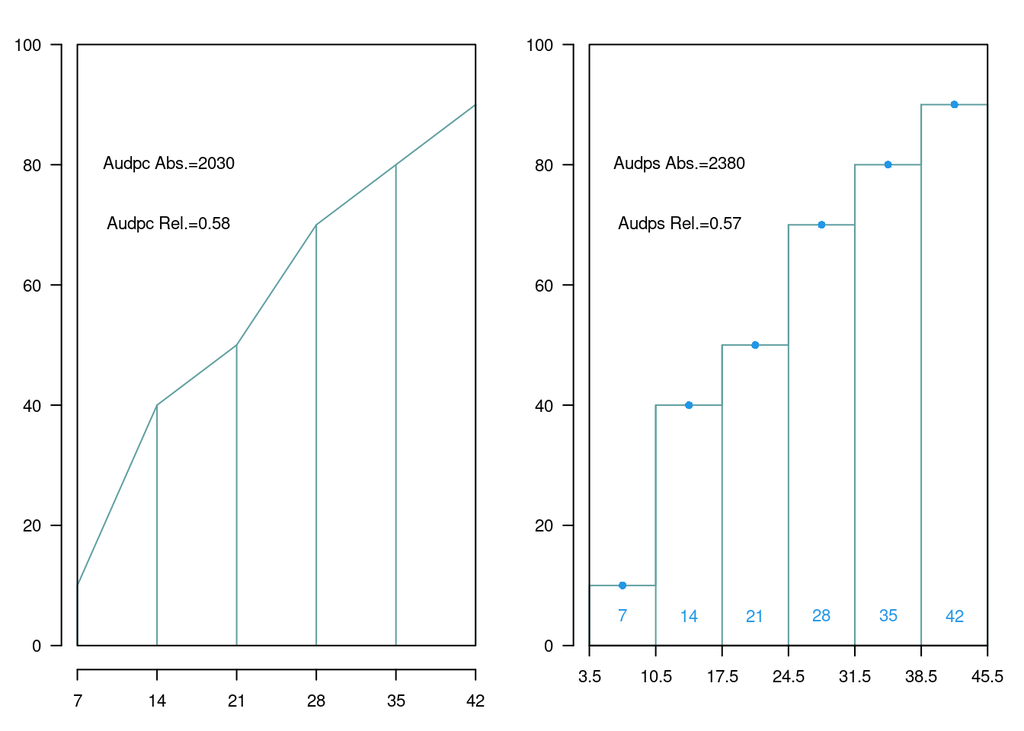

Figure 9.5: Area under the curve (AUDPC) and Area under the Stairs (AUDPS)

## 9.17 Non-Additivity

Tukey’s test for non-additivity is used when there are doubts about the additivity veracity of a model. This test confirms such assumption and it is expected to accept the null hypothesis of the non-additive effect of the model.

For this test, all the experimental data used in the estimation of the linear additive model are required.

Use the function `nonadditivity()` of **agricolae**. For its demonstration, the experimental data “potato”, of the package **agricolae**, will be used. In this case, the model corresponds to the randomized complete block design, where the treatments are the varieties.

```r
data(potato)
potato[,1]<-as.factor(potato[,1])
model<-lm(cutting ~ date + variety,potato)
df<-df.residual(model)
MSerror<-deviance(model)/df
analysis<-with(potato,nonadditivity(cutting, date, variety, df, MSerror))
```

```
Tukey's test of nonadditivity
cutting

P : 15.37166
Q : 77.44441

Analysis of Variance Table

Response: residual
              Df Sum Sq Mean Sq F value Pr(>F)
Nonadditivity  1  3.051  3.0511   0.922 0.3532
Residuals     14 46.330  3.3093
```

According to the results, the model is additive because the p.value 0.35 is greater than 0.05.

## 9.18 LATEBLIGHT

LATEBLIGHT is a mathematical model that simulates the effect of weather, host growth and resistance, and fungicide use on asexual development and growth of Phytophthora infestans on potato foliage, see Figure 9.6

LATEBLIGHT Version LB2004 was created in October 2004 (Andrade-Piedra et al., 2005a, b and c), based on the C-version written by B.E. Ticknor (‘BET 21191 modification of cbm8d29.c’), reported by Doster et al. (1990) and described in detail by Fry et al. (1991) (This version is referred as LB1990 by Andrade-Piedra et al. [2005a]). The first version of LATEBLIGHT was developed by Bruhn and Fry (1981) and described in detail by Bruhn et al. (1980).

```r
options(digits=2)
f <- system.file("external/weather.csv", package="agricolae")
weather <- read.csv(f,header=FALSE)
f <- system.file("external/severity.csv", package="agricolae")
severity <- read.csv(f)
weather[,1]<-as.Date(weather[,1],format = "%m/%d/%Y")
# Parameters dates
dates<-c("2000-03-25","2000-04-09","2000-04-12","2000-04-16","2000-04-22")
dates<-as.Date(dates)
EmergDate <- as.Date("2000/01/19")
EndEpidDate <- as.Date("2000-04-22")
dates<-as.Date(dates)
NoReadingsH<- 1
RHthreshold <- 90
WS<-weatherSeverity(weather,severity,dates,EmergDate,EndEpidDate,
NoReadingsH,RHthreshold)
# Parameters to Lateblight function
InocDate<-"2000-03-18"
LGR <- 0.00410
IniSpor <- 0
SR <- 292000000
IE <- 1.0
LP <- 2.82
InMicCol <- 9
Cultivar <- "NICOLA"
ApplSys <- "NOFUNGICIDE"
main<-"Cultivar: NICOLA"
```

```r
oldpar<-par(mar=c(3,3,4,1),cex=0.7)
#--------------------------
model<-lateblight(WS, Cultivar,ApplSys, InocDate, LGR,IniSpor,SR,IE,
LP,MatTime='LATESEASON',InMicCol,main=main,type="l",xlim=c(65,95),lwd=1.5,
xlab="Time (days after emergence)", ylab="Severity (Percentage)")
```

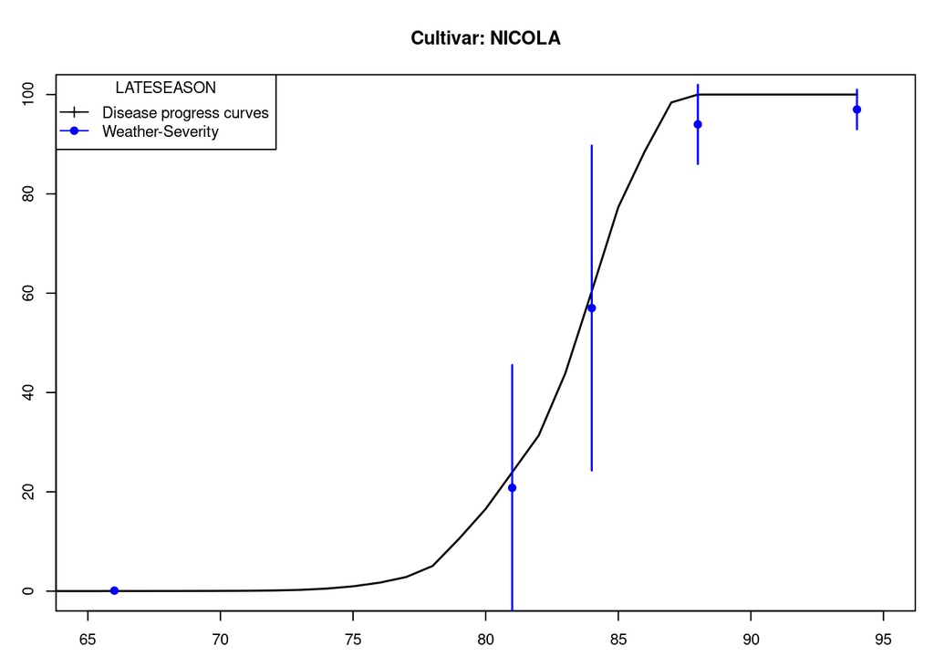

Figure 9.6: LATESEASON

```r
par(oldpar)
```

```r
head(model$Gfile)
```

```
           dates nday MeanSeverity StDevSeverity MinObs MaxObs
Eval1 2000-03-25   66          0.1             0    0.1    0.1
Eval2 2000-04-09   81         20.8            25   -3.9   45.5
Eval3 2000-04-12   84         57.0            33   24.3   89.7
Eval4 2000-04-16   88         94.0             8   86.0  102.0
Eval5 2000-04-22   94         97.0             4   93.0  101.0
```

```r
str(model$Ofile)
```

```
'data.frame':   94 obs. of  13 variables:
 $ Date       : Date, format: "2000-01-20" "2000-01-21" ...
 $ nday       : num  1 2 3 4 5 6 7 8 9 10 ...
 $ MicCol     : num  0 0 0 0 0 0 0 0 0 0 ...
 $ SimSeverity: num  0 0 0 0 0 0 0 0 0 0 ...
 $ LAI        : num  0.01 0.0276 0.0384 0.0492 0.06 0.086 0.112 0.138 0.164 0.19 ...
 $ LatPer     : num  0 2 2 2 2 2 2 2 2 2 ...
 $ LesExInc   : num  0 0 0 0 0 0 0 0 0 0 ...
 $ AttchSp    : num  0 0 0 0 0 0 0 0 0 0 ...
 $ AUDPC      : num  0 0 0 0 0 0 0 0 0 0 ...
 $ rLP        : num  0 0 0 0 0 0 0 0 0 0 ...
 $ InvrLP     : num  0 0 0 0 0 0 0 0 0 0 ...
 $ BlPr       : num  0 0 0 0 0 0 0 0 0 0 ...
 $ Defol      : num  0 0 0 0 0 0 0 0 0 0 ...
```

```r
head(model$Ofile[,1:7])
```

```
        Date nday MicCol SimSeverity   LAI LatPer LesExInc
1 2000-01-20    1      0           0 0.010      0        0
2 2000-01-21    2      0           0 0.028      2        0
3 2000-01-22    3      0           0 0.038      2        0
4 2000-01-23    4      0           0 0.049      2        0
5 2000-01-24    5      0           0 0.060      2        0
6 2000-01-25    6      0           0 0.086      2        0
```

**Repeating graphic**

```r
x<- model$Ofile$nday
y<- model$Ofile$SimSeverity
w<- model$Gfile$nday
z<- model$Gfile$MeanSeverity
Min<-model$Gfile$MinObs
Max<-model$Gfile$MaxObs
```

```r
oldpar<-par(mar=c(3,2.5,1,1),cex=0.7)
plot(x,y,type="l",xlim=c(65,95),lwd=1.5,xlab="Time (days after emergence)",
ylab="Severity (Percentage)")
points(w,z,col="red",cex=1,pch=19); npoints <- length(w)
for ( i in 1:npoints)segments(w[i],Min[i],w[i],Max[i],lwd=1.5,col="red")
legend("topleft",c("Disease progress curves","Weather-Severity"),
title="Description",lty=1,pch=c(3,19),col=c("black","red"))
par(oldpar)
```

# References

Cochran, W. G., and Cox, G. M. (1992). *Experimental Designs*. John Wiley & Sons, New York.

Conover, W. J. (1999). Practical Nonparametric Statistics.

Crossa, J. (1990). “Statistical Analyses of Multilocation Trials,” in *Advances in agronomy* (Elsevier), 55–85.

Haynes, K. G., Lambert, D. H., Christ, B. J., Weingartner, D. P., Douches, D. S., Backlund, J. E., et al. (1998). Phenotypic stability of resistance to late blight in potato clones evaluated at eight sites in the United Stated. 75, 211–217.

Hsu, J. C. (1996). *Multiple Comparisons: Theory and Methods*. Chapman; Hall/CRC.

Joshi, D. D. (1987). *Linear Estimation and Design of Experiments*. Wiley Eastern Limited, New Delhi, India.

Kuehl, R. O. (2000). *Designs of Experiments: Statistical Principles of Research Design and Analysis*. Duxbury Press.

Le Clerg, E. L., Leonard, W. H., Erwin, L., Warren, H. L., and Andrew, G. C. (1962). *Field Plot Techniques*. Burgess Publishing Company, Minneapolis, Minnesota.

Mendiburu, F. de (2009). Una herramienta de análisis estadístico para la investigación agrícola.

Montgomery, D. C. (2002). *Design and Analysis of Experiments*. John Wiley & Sons, New York.

N., S., H.Sabaghpour, S., and Dehghani, H. (2008). The use of an AMMI model and its parameters to analyse yield stability in multienvironment trials. *Journal of Agricultural Science* 146, 571–581.

Purchase, J. L. (1997). Parametric analysis to describe genotype environment interaction and yield stability in winter wheat.

R Core Team (2020). *R: A Language and Environment for Statistical Computing*. Vienna, Austria: R Foundation for Statistical Computing Available at: https://www.R-project.org/.

Singh, R. K., and Chaudhary, B. D. (1979). *Biometrical Methods in Quantitative Genetic Analysis*. Kalyani Publishers.

Steel, Torry, and Dickey (1997). *Principles and Procedures of Statistic a Biometrical Approach*. The McGraw Hill Companies, Inc.

Waller, R. A., and Duncan, D. B. (1969). A Bayes Rule for the Symmetric Multiple Comparisons Problem. *Journal of the American Statistical Association* 64, 1484–1503.